# AE 05: Battle of the Budget Airlines

Suggested answers

Application exercise

```r
library(tidyverse)
library(nycflights23)
```

## NYC Flights

- To demonstrate data wrangling we will use `flights`, a tibble in the **nycflights23** R package. *Note: this is an updated version of the package we used last time!*
- The data set includes characteristics of all flights departing from New York City (JFK, LGA, EWR) in 2023.

**Caution**

If you have already loaded nycflights13, nycflights23 might not load properly, since they are two packages that contain data sets with the same names. If this is causing problems, click Session -> Restart R and Clear Outputs.

## EDA: Battle of the Budget Airlines

There’s a good chance you’ve either experienced or heard about the joys of flying with Spirit and Frontier airlines. They get you where you want to go - no more, no less (well, maybe less) - at a very cheap cost. *But which is worse??* Specifically, which of the two airlines has a higher proportion of flights with a delayed arrival time?

Create a data visualization and compute corresponding summary statistics that investigate this question.

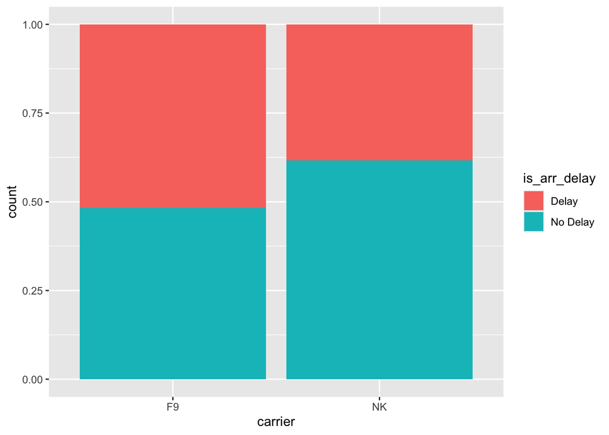

```r
flights |>
  filter(carrier %in% c("F9", "NK")) |>
  mutate(is_arr_delay = ifelse(arr_delay > 0, "Delay", "No Delay")) |>
  filter(!is.na(arr_delay)) |>
  ggplot(aes(x = carrier, fill = is_arr_delay)) +
  geom_bar(position = "fill")
```

```r
flights |>
  filter(carrier %in% c("F9", "NK")) |>
  mutate(is_arr_delay = ifelse(arr_delay > 0, "Delay", "No Delay")) |>
  filter(!is.na(arr_delay)) |>
  count(carrier, is_arr_delay) |>
  group_by(carrier) |>
  mutate(total = sum(n)) |>
  mutate(n = n/total)
```

```
# A tibble: 4 × 4
# Groups:   carrier [2]
  carrier is_arr_delay     n total
  <chr>   <chr>        <dbl> <int>
1 F9      Delay        0.517  1218
2 F9      No Delay     0.483  1218
3 NK      Delay        0.384 14769
4 NK      No Delay     0.616 14769
```

**Questions:**

Can you use this data to make comments about *all* Spirit and Frontier flights, or just those leaving New York? Is there anything that might cause this comparison to be unfair?

## More EDA

Maybe you care more about how much the delays are by than whether or not there is a delay. If one airline has a lot of delays, but they are all by 5 minutes, does it really matter??

Now, create a data visualization and compute summary statistics that compare delay times for delayed flights. Now which airline is worse? Has this changed your answer?

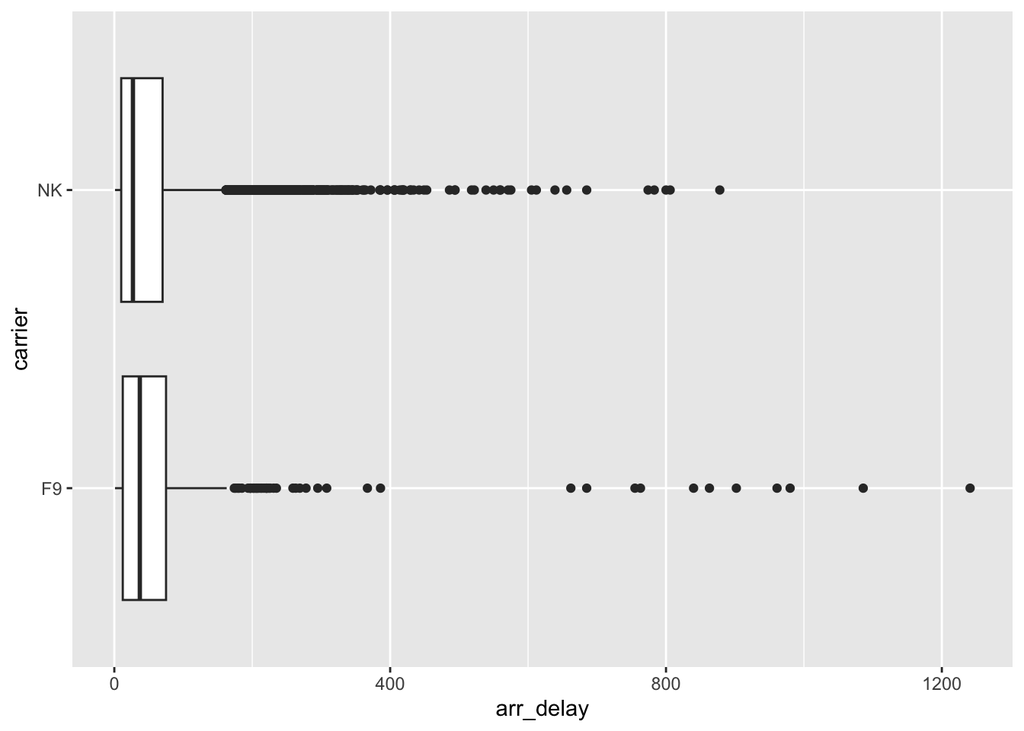

```r
flights |>
  filter(carrier %in% c("F9", "NK")) |>
  filter(arr_delay > 0) |>
  ggplot(aes(x = arr_delay, y = carrier)) +
  geom_boxplot()
```

```r
flights |>
  filter(carrier %in% c("F9", "NK")) |>
  filter(arr_delay > 0) |>
  group_by(carrier) |>
  summarise(mean = mean(arr_delay),
            median = median(arr_delay),
            Q1 = quantile(arr_delay, 0.25),
            Q3 = quantile(arr_delay, 0.75))
```

```
# A tibble: 2 × 5
  carrier  mean median    Q1    Q3
  <chr>   <dbl>  <dbl> <dbl> <dbl>
1 F9       67.5     37  12.2    75
2 NK       54.7     27  10      70
```